# Afghanistan Case Study

```r
library(tidyverse)
library(readxl)
library(p8105.datasets)
library(hexbin)
library(patchwork)
library(leaflet)
library(lubridate)
library(xml2)
library(rvest)
library(plotly)

devtools::install_github("benmarwick/wordcountaddin",  type = "source", dependencies = TRUE)
knitr::opts_chunk$set(
  fig.width = 6,
  fig.asp = .6,
  out.width = "90%"
)
theme_set(theme_minimal() + theme(legend.position = "bottom"))
options(
  ggplot2.continuous.colour = "viridis",
  ggplot2.continuous.fill = "viridis"
)
scale_colour_discrete = scale_colour_viridis_d
scale_fill_discrete = scale_fill_viridis_d
```

##Explain

Aidworker dataset - cleaning and tailoring

```r
#Kailey notes: from section 1 cleaning and filtered for afghanistan/year

url = "https://aidworkersecurity.org/incidents/search"
aidworker_html = read_html(url)

aidworker_df =
  aidworker_html %>%
  html_nodes(css = "table") %>%
  first() %>%
  html_table() %>%
  as_tibble()

afghan_aidworker_df =
  aidworker_df %>%
  janitor::clean_names() %>%
  select(-source, -verified) %>%
  rename(year = year_sort_descending) %>%
  mutate(intl_org_affected =
           case_when(
             un != 0 ~ "yes",
             ingo != 0 ~ "yes",
             icrc != 0 ~ "yes",
             ifrc != 0 ~ "yes",
             other != 0 ~ "yes",
             lngo_and_nrcs != 0 ~ "no"),
         intl_org_affected = as.factor(intl_org_affected)) %>%
  relocate(id, month, day, year, country, intl_org_affected) %>%
  filter(country == "Afghanistan") %>%
  filter(year %in% c("2008", "2009", "2010", "2011", "2012", "2013", "2014", "2015", "2016"))
```

## Kailey notes: I found it! This pivot longer is making the duplicates occur when added to the code chunk above.. also, this date code is not working for me!

pivot_longer( un:other, names_to = “org_type”, values_to = “number_orgs_affected” ) %>% select(-number_orgs_affected)

aidworker_df$date <- as.Date(with(afghan_aidworker_df, paste(year, month, day, sep = “-”)), “%Y-%m-%d”)

## Starting EDA and vis

Internationals vs. nationals killed (Not in the to-do list but has an interesting spikes and dips; check historical context?)

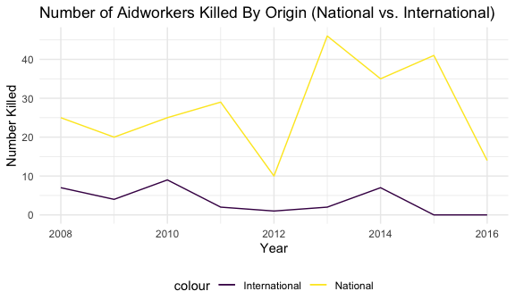

```r
#Kailey notes: FINALLY figured this out. got rid of all duplicates and strange number counts.

afghan_aidworker_international_df =
  afghan_aidworker_df %>%
  group_by(year) %>%
  summarise(sum(internationals_killed)) %>%
  mutate(
    internationals_killed_tot = `sum(internationals_killed)`
  ) %>%
  select(year, internationals_killed_tot)
afghan_aidworker_national_df =
  afghan_aidworker_df %>%
  group_by(year) %>%
  summarise(sum(nationals_killed)) %>%
  mutate(
    nationals_killed_tot = `sum(nationals_killed)`
  ) %>%
  select(year, nationals_killed_tot)
afghan_aidworker_df_new =
  left_join(afghan_aidworker_international_df, afghan_aidworker_national_df, by = "year")


afghan_aidworker_df_new %>%
     ggplot(aes(x = year, y = internationals_killed_tot, col = "International")) +
   geom_line() +
  geom_line(aes(x = year, y = nationals_killed_tot, col = "National")) +
  labs(
    title = "Number of Aidworkers Killed By Origin (National vs. International)",
    x = "Year",
    y = "Number Killed"
  )
```

More visualizations using aidworker df

```r
# Kailey notes: Not sure if this visualization is 100% complete in terms of making sense/usefulness but I think something like this could be interesting. Subplotted two interactive plots. You can see the means of attack next to the attack context. For example, the aerial bombardment spike in 2015 is tied to combat/crossfire attack type (could look at historical context here). Can also see that in 2009 there were 16 kidnappings due to an ambush. Open to thoughts on this but thought something like this could be cool.


means_attack_p =
afghan_aidworker_df %>%
  plot_ly(
    x = ~year, y = ~total_victims, color = ~means_of_attack,
    type = "scatter") %>%
    layout(
    title = "Victims per year by attack type")

attack_context_p =
afghan_aidworker_df %>%
  plot_ly(
    x = ~year, y = ~total_victims, color = ~attack_context,
    type = "scatter") %>%
    layout(
    title = "Victims per year by attack context")

subplot(means_attack_p, attack_context_p)
```

[output not shown]

[output not shown]

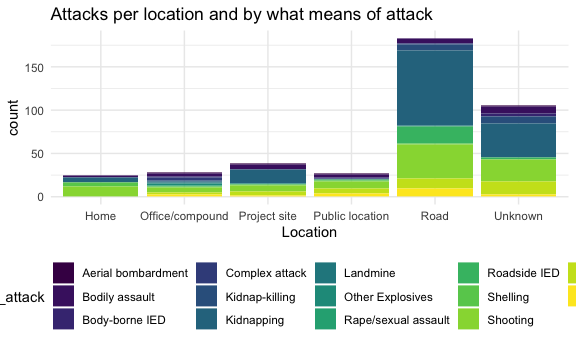

```r
afghan_aidworker_df %>%
     ggplot(aes(x = location, fill = means_of_attack)) +
   geom_bar() +
  labs(
    title = "Attacks per location and by what means of attack",
    x = "Location"
  )
```

From section 1 vis:

looking at frequency of attacks on staff of various organizations yes/no

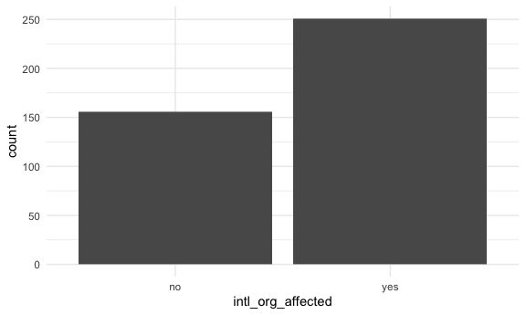

```r
afghan_aidworker_df %>%
  ggplot(aes(x = intl_org_affected)) +
  geom_bar()
```

International vs National staff attacks?

```r
af_pct_intl_ntl =
afghan_aidworker_df %>%
  group_by(year) %>%
  summarize(tot_national = sum(total_national_staff),
            tot_intl = sum(total_international_staff),
            tot_both = sum(total_victims),
            pct_intl = (tot_intl/tot_both)*100,
            pct_national = (tot_national/tot_both)*100) %>%
  ggplot(aes(x = year, y = pct_national, col = 3)) +
  geom_line() +
   geom_line(aes(x = year, y = pct_intl, col = 2)) +
   labs(
    x = "Year",
    y = "% Attacked"
   )
## Would still need to add labels for understanding
```

## Kailey notes: need to scrape uppsala data from web instead of loading in by .csv